# Métodos iterativos para inferência paramétrica

Gustavo Almeida Silva

## Questão 1

### A

Nessa primeira questão, iremos utilizar metodos numericos, atarves da função **optim()**, para maximar a função de log-verossimilhnça da distribuição $Gama(\alpha,\beta)$

Obtivemos a função de log-verossimilhnça da seguinte forma:

Seja $X\text{~}Gama(\alpha,\beta)$, $X$ possui a seguinte função de densidade
$$Gama(\alpha,\beta)=\frac{\beta ^{\alpha }}{\Gamma \left(\alpha \right)}\cdot \:x^{\alpha -1}\cdot \:exp\left(-\beta \:x\right)$$
Para encontrar a função de verossimilhnça, estaremos tratando de um caso amostral, e portanto a $f.d.p$ conjunta é dada como

$$\prod_{i=1}^N \:\frac{\beta ^{\alpha }}{\Gamma \left(\alpha \right)}\cdot \:x_i^{\alpha -1}\cdot \:exp\left(-\beta \:x_i\right)$$

Assim, utilizando a função **optim**, iremos maximizar a função em $\alpha,\beta$

```r
ll_func_gamma = function(data_sample,params1,params2){
  ifelse(params1='shape' && params2='rate',shape0=params1,rate0=params2)
      shape0=as.character(params1)
      rate0=as.character(params2)

    obj_func=dgamma

    obj_func=lapply(c(shape0,rate0),obj_func)
    sum_func=call(obj_func)
    final_func=log(eval(sum_func))

}
```

Testaremos a função com 2 exemplos, o primeiro utilizando o gerador de numeros aleatorios do proprio R (dados1), e o segundo utilizando os dados retirados da questão **7.10.c** do livro do Casella (dados2)

```r
sample_example1=rgamma(500,shape=1,rate = 2)
sample_example2=c(22.0,23.9,20.9,23.8,25,24,21.7,23.8,22.8,23.1,23.1,23.5,23,23)
```

### Iteração dados - 1

```r
ll_gamma1 = ll_func_gamma(data_sample=sample_example1,params1='shape',params2='rate')
estimated_params1 = optim(c(0,0), ll_gamma1, method = c("L-BFGS-B"),control=list(fnscale=-1), lower = 0.001)$par
```

Tivemos os seguintes parametros estimados: $\alpha=$ 1.0447019 $\beta=$ 2.0723139

### Iteração dados - 2

```r
ll_gamma2 = ll_func_gamma(data_sample=sample_example2,params1='shape',params2='rate')
estimated_params2 = optim(c(0,0), ll_gamma2, method = c("L-BFGS-B"),control=list(fnscale=-1), lower = 0.001)$par
```

Tivemos os seguintes parametros estimados: $\alpha=$ 514.3357437 $\beta=$ 22.2518554

### B.1

Sabemos que não é possivel encontrar funções explicitas de $\alpha$ e de $\beta$ no para estimação parametrica. Assim, uma outra forma de encontarmos esses parametros é reduzir o problema a maximização de uma função univaridada.

Nesse exemplo, encontraremos uma função de $\beta$ com o termo independente $\alpha$

### Gride de valores dados - 1

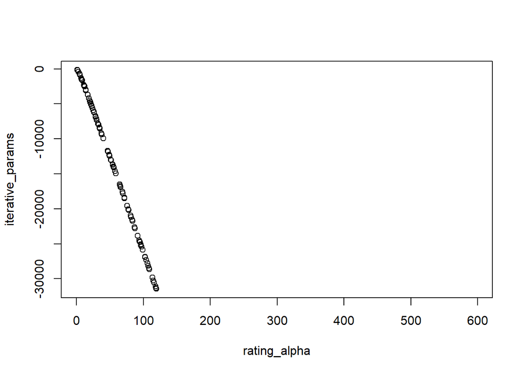

```r
sample_mean1=mean(sample_example1)
rating_alpha=runif(500,-1,600)
beta_estimated=rating_alpha/sample_mean1


iterative_params=sapply(seq_along(rating_alpha), function(i) ll_gamma1(c(rating_alpha[i], beta_estimated[i])))
plot(rating_alpha,iterative_params)
```

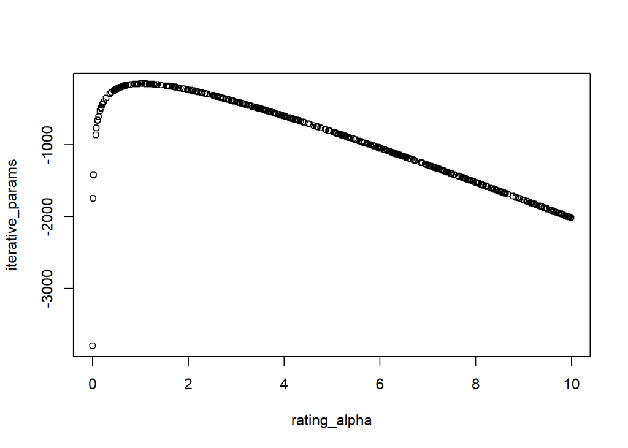

```r
rating_alpha=runif(500,0,10)
beta_estimated=rating_alpha/sample_mean1


iterative_params=sapply(seq_along(rating_alpha), function(i) ll_gamma1(c(rating_alpha[i], beta_estimated[i])))
plot(rating_alpha,iterative_params)
```

```r
find_max=which.max(iterative_params)
rating_alpha=rating_alpha[find_max]
beta_estimated=rating_alpha/sample_mean1
```

Assim, temos os seguintes parametros estimados: $\alpha=$ 1.0287793 $\beta=$ 2.0407292

### Gride de valores dados - 2

```r
sample_mean2=mean(sample_example2)
rating_alpha=runif(500,-1,600)
beta_estimated=rating_alpha/sample_mean2


iterative_params=sapply(seq_along(rating_alpha), function(i) ll_gamma2(c(rating_alpha[i], beta_estimated[i])))
```

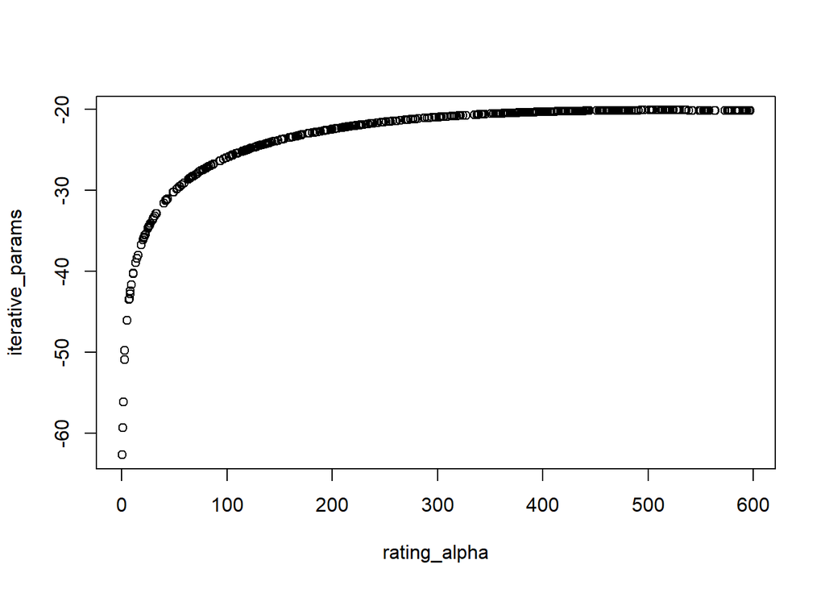

```r
plot(rating_alpha,iterative_params)
```

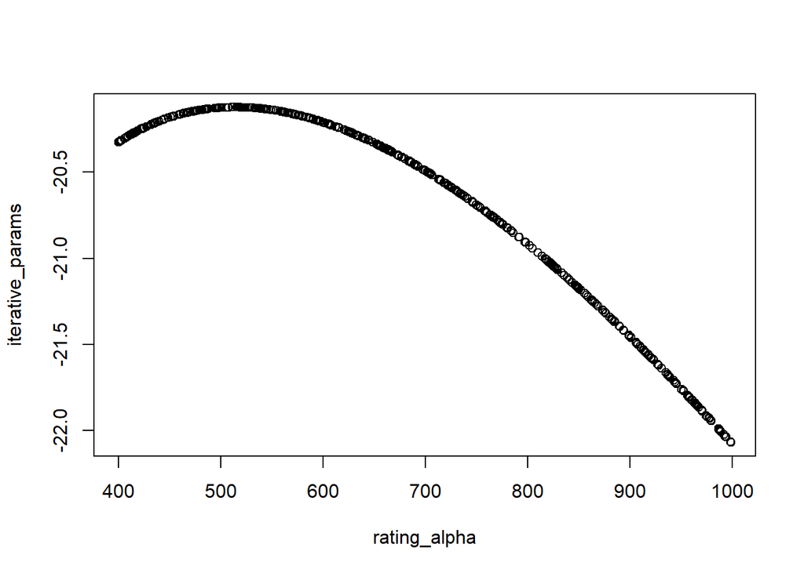

```r
rating_alpha=runif(500,400,1000)
beta_estimated=rating_alpha/sample_mean2


iterative_params=sapply(seq_along(rating_alpha), function(i) ll_gamma2(c(rating_alpha[i], beta_estimated[i])))
plot(rating_alpha,iterative_params)
```

```r
find_max=which.max(iterative_params)
rating_alpha=rating_alpha[find_max]
beta_estimated=rating_alpha/sample_mean2
```

Assim, temos os seguintes parametros estimados: $\alpha=$ 515.8390141 $\beta=$ 22.3168918

### B.2

### Optim em dados - 1

```r
to_max_ll = function(alpha){
  beta = alpha/mean(sample_example1)
  ll_gamma1(c(alpha, beta))
}

beta_estimated=mean(sample_example1)/var(sample_example1)
rating_alpha=mean(sample_example1)*beta_estimated
```

```r
alpha=optim(rating_alpha, to_max_ll,
      method = c("L-BFGS-B"),
      control=list(fnscale=-1), lower = 0.001)$par
beta = alpha/mean(sample_example1)
```

### Optim em dados - 2

```r
to_max_ll = function(alpha){
   # Calculando beta
  beta = alpha/mean(sample_example2)
   # calculando a verossimilhança
  ll_gamma2(c(alpha, beta))
}

beta_estimated=mean(sample_example2)/var(sample_example2)
rating_alpha=mean(sample_example2)*beta_estimated
```

```r
alpha=optim(rating_alpha, to_max_ll,
      method = c("L-BFGS-B"),
      control=list(fnscale=-1), lower = 0.01)$par
beta = alpha/mean(sample_example2)
```

## Questão 2

### Bolfarine e Sandoval

Seja X uma **v.a** com $f.d.p$
$$f(x;\theta)=\frac{1}{2}(1+\theta x)\text{, }-1\leq x\leq1\text{, }-1\leq \theta\leq1$$
Para estimar o seu parametro $\theta$ via **Newton-Raphson-** primeiro temos que encontrar valores amostrais dessa distribuição.

Como o R não possui um gerador proprio para essa **v.a**, podemos utilizar o método da função quantilica ou o método da aceitação-reijeição para a geração de valores amostrais

Faremos os testes utilizando os 2 metodos

### Geração via quantilica

Para gerarmos os valores via função quantilica temos que seguir 3 passos.

- Encontrar sua **f.d.a**
- Encontrar a inversa da **f.d.a**, chamada de função quantilica
- Utilizar metodo Monte Carlo como dominio dessa função visando encontrar **f(x)**

(Fixaremos $\theta=0.5$ para os exemplos)

```r
bolfarine_gen_quant=function(teta){
u=runif(1000,0,1)
(-1+sqrt(1+4*teta*u-2*teta+(teta**2)))/teta
}

func_alva=function(x) (1+0.5*x)/2
bolfarine_sample_quant=bolfarine_gen_quant(0.5)
```

### Geração via aceitação-rejeição

A geração via método da aceitação-rejeição surge como alternativa ao metodo da função quantilica. Ele é utilizado quando o calculo da **f.d.a** (que utiliza uma integral) se torna muito complicado ou quando a sua **f.d.a** não possui função inversa explícita.

Temos que seguir os seguintes passos nesse método

- Utilizar sua **f.d.p** como função de alvo
- Utilizar alguma outra distribuição com gerador aleatório conhecido como auxiliar, onde essa função auxiliar deve ter $f_{aux}(k)>f_{alvo}(k)k $
- Utilizar valores aleatórios da função auxiliar para obter valores da função alvo

```r
bolfarine_gen_rej_acep=function(teta){

  ##Armazenando a função alva
  obj_func=function(x) (1+teta*x)/2

  ##Armazenando a função candidata
  aux_func=function(x)dunif(x,min=-1,max=1)

  obj=vector()
  M <- optimize(f = function(x)obj_func(x)/aux_func(x), interval = c(-1,1), maximum = T)$objective

  #Utilizando o metodo da aceitação rejeicao para a criacao dos valores aleatorios
  j=1
  for(i in 1:1000){
    u=runif(1)
    y=runif(1,-1,1)
    if(u*M<=obj_func(y)/aux_func(y)){
      obj[j]=  y
      j=j+1
    }
  }
  return(obj)
}
```

```r
bolfarine_sample_rej_acep=bolfarine_gen_rej_acep(0.5)
```

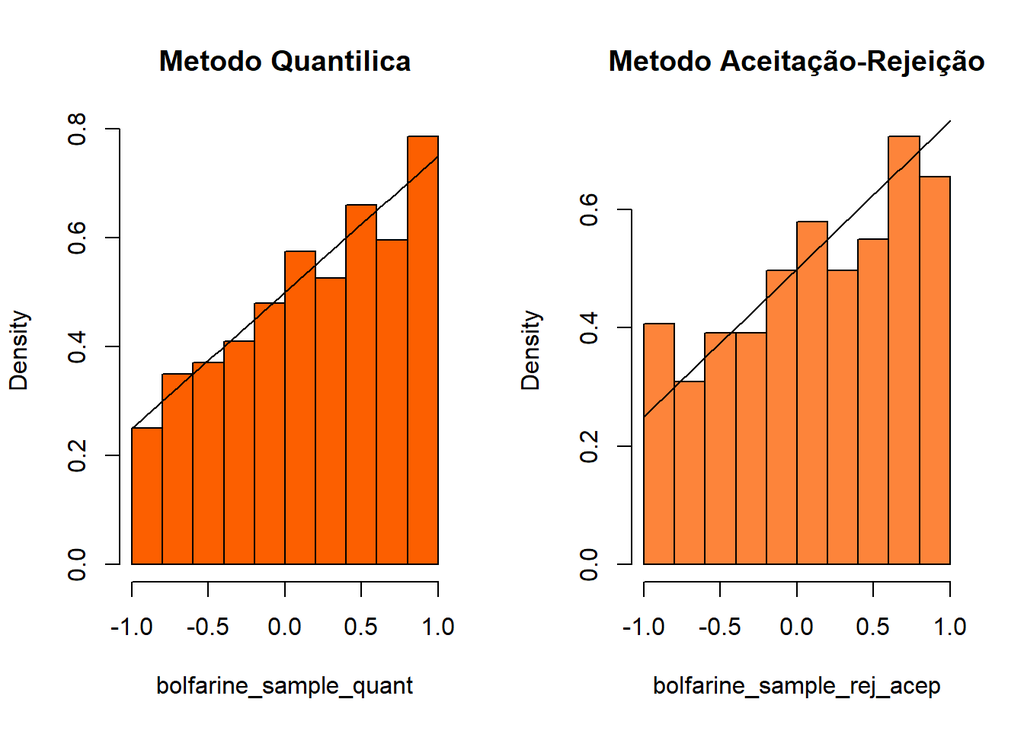

```r
par(mfrow=c(1,2))
hist(bolfarine_sample_quant,xlim=c(-1,1),freq = F,main='Metodo Quantilica',col='#FC5F00')
curve(func_alva,-1,1,add = T)
hist(bolfarine_sample_rej_acep,xlim=c(-1,1),freq = F,main='Metodo Aceitação-Rejeição',col='#FD843A')
curve(func_alva,-1,1,add = T)
```

### Estimação de $\theta$

```r
iterative_bolfarine=function(data,error_choice=1e-6){

  teta_estim=mean(data)
  s_teta=function(teta_hat) sum(data/(1+(teta_hat*data)))
  h_teta=function(teta_hat) sum((data**2)/((1+teta_hat*data)**2))

  error_eval=1
  i=1
  while(error_eval>error_choice)
  {
    teta_estim[i+1]=teta_estim[i]+(s_teta(teta_estim[i])/h_teta(teta_estim[i]))
    error_eval=teta_estim[i+1]-teta_estim[i]
    print(teta_estim)
    i=i+1
  }

  return(teta_estim[i])
}
```

```r
ite_bol_quant=iterative_bolfarine(bolfarine_sample_quant)
```

```
## [1] 0.1684247 0.5298205
## [1] 0.1684247 0.5298205 0.5041743
```

```r
ite_bol_AR=iterative_bolfarine(bolfarine_sample_rej_acep)
```

```
## [1] 0.1258606 0.3768641
## [1] 0.1258606 0.3768641 0.3665911
```

Obtivemos os seguintes resultados: $\theta$ via metodo quantílica = 0.5041743 $\theta$ via metodo aceitação-rejeição = 0.3665911

### Cauchy

Seja $X$ uma **v.a**, onde $X\text{~}Cauchy(\theta)$, com **f.d.p**
$$f_X(x;\theta)=\pi(1+(x-\theta)^2)^{-1}$$

```r
iterative_cauchy=function(data,error_choice=1e-6){

  teta_estim=mean(data)
  s_teta=function(teta_hat) sum(2*(data-teta_hat)/(1+((data - teta_hat)**2)))
  h_teta=function(teta_hat) 2*sum((1-((data-teta_hat)**2))/((1+((data - teta_hat)**2))**2))

  error_eval=1
  i=1
  while(error_eval>error_choice)
    {
      teta_estim[i+1]=teta_estim[i]+(s_teta(teta_estim[i])/h_teta(teta_estim[i]))
      error_eval=teta_estim[i+1]-teta_estim[i]
      print(teta_estim)
        i=i+1
    }

   return(teta_estim)
  }
```

Gerando valores aleatórios utilizando o gerador do próprio R

```r
cauchy_sample=rcauchy(100,1)
mean(cauchy_sample)
```

```
## [1] 2.049868
```

```r
iterative_cauchy(cauchy_sample)
```

```
## [1] 2.0498680 0.3902117
```

[output not shown]